### Author: Leonardo Picchiami

# Weights Strategies Analysis

This file shows the weights and its distribution to applying the two weight calculation strategies to modify the weight of the graph edges of the ds-1 data set along the timeline. The first strategy is the calculation of weights through the fraction of the co-citations made by the authors who have all worked together at least once between them; the second strategy is the number of co-citations for keywords pair (pair of nodes).

```python
import warnings
warnings.filterwarnings("ignore")

import sys

#Add path for class developed import
sys.path.append("..")

import graph as gr

ds1_path = '../../../dataset_src/ds-1.tsv'
ds2_path = '../../../dataset_src/ds-2.tsv'
```

Calculation of weights according to both strategies, edges-weights printing and plotting.

```python
def year_weights_configs(year):
    graph = gr.YearGraph(ds1_path, ds2_path, year)
    graph.read()

    print("Weights config: fraction of co-citations keywords by cooperating authors.")
    graph.weights_fraction_cocitations()
    graph.plot_weights()
    print(graph.get_weights())

    print("{0}Weights config: number of co-citated keywords.".format('\n\n\n'))
    graph.weights_number_cocitations()
    graph.plot_weights()
    print(graph.get_weights())
```

In the next pieces of code we will print weights of the edges and will plot their distributions for each year of timeline

## Year 2000

```
Year: 2000

Weights config: fraction of co-citations keywords by cooperating authors.
```

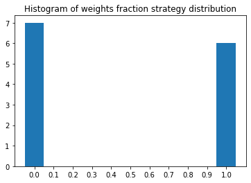

```
{('artificial neural network', 'neural network simulation'): 0.0, ('nonlinear system', 'simulation'): 1.0, ('nonlinear system', 'motion estimation\xa0'): 1.0, ('simulation', 'motion estimation\xa0'): 1.0, ('support vector machine', 'feature vector'): 1.0, ('support vector machine', 'experiment'): 1.…



Weights config: number of co-citated keywords.
```

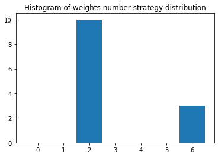

```
{('artificial neural network', 'neural network simulation'): 2, ('nonlinear system', 'simulation'): 6, ('nonlinear system', 'motion estimation\xa0'): 6, ('simulation', 'motion estimation\xa0'): 6, ('support vector machine', 'feature vector'): 2, ('support vector machine', 'experiment'): 2, ('feature…
```

```python
print("Year: 2000{0}".format('\n'))

year_weights_configs("2000")
```

## Year 2001

```
Year: 2001

Weights config: fraction of co-citations keywords by cooperating authors.
```

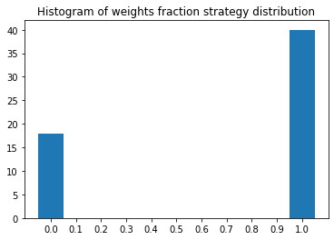

```
{('signal processing algorithms', 'filtering algorithms'): 1.0, ('signal processing algorithms', 'signal processing'): 1.0, ('state-space methods', 'mathematics'): 1.0, ('state-space methods', 'state estimation'): 1.0, ('state-space methods', 'signal processing'): 1.0, ('mathematics', 'signal proces…



Weights config: number of co-citated keywords.
```

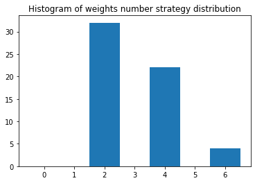

```
{('signal processing algorithms', 'filtering algorithms'): 4, ('signal processing algorithms', 'signal processing'): 6, ('state-space methods', 'mathematics'): 4, ('state-space methods', 'state estimation'): 6, ('state-space methods', 'signal processing'): 6, ('mathematics', 'signal processing'): 4,…
```

```python
print("Year: 2001{0}".format('\n'))

year_weights_configs("2001")
```

## Year 2002

```
Year: 2002

Weights config: fraction of co-citations keywords by cooperating authors.
```

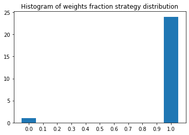

```
{('bayesian methods', 'monte carlo methods'): 1.0, ('bayesian methods', 'signal processing'): 1.0, ('monte carlo methods', 'signal processing'): 1.0, ('filtering algorithms', 'state estimation'): 1.0, ('lyapunov function', 'global exponential stability'): 1.0, ('independent component analysis', 'bli…



Weights config: number of co-citated keywords.
```

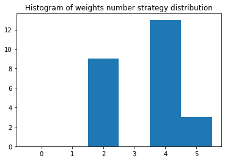

```
{('bayesian methods', 'monte carlo methods'): 5, ('bayesian methods', 'signal processing'): 5, ('monte carlo methods', 'signal processing'): 5, ('filtering algorithms', 'state estimation'): 2, ('lyapunov function', 'global exponential stability'): 2, ('independent component analysis', 'blind source …
```

```python
print("Year: 2002{0}".format('\n'))

year_weights_configs("2002")
```

## Year 2003

```
Year: 2003

Weights config: fraction of co-citations keywords by cooperating authors.
```

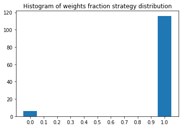

```
{('85.40.ls', '43.80.+p'): 1.0, ('85.40.ls', '87.10.+e'): 1.0, ('43.80.+p', '87.10.+e'): 1.0, ('filtering', 'state-space methods'): 1.0, ('filtering', 'state estimation'): 1.0, ('state-space methods', 'state estimation'): 1.0, ('87.18.sn', 'global exponential stability'): 1.0, ('87.18.sn', '85.40.ls…



Weights config: number of co-citated keywords.
```

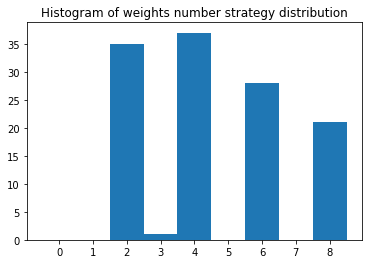

```
{('85.40.ls', '43.80.+p'): 4, ('85.40.ls', '87.10.+e'): 4, ('43.80.+p', '87.10.+e'): 4, ('filtering', 'state-space methods'): 4, ('filtering', 'state estimation'): 4, ('state-space methods', 'state estimation'): 4, ('87.18.sn', 'global exponential stability'): 4, ('87.18.sn', '85.40.ls'): 4, ('87.18…
```

```python
print("Year: 2003{0}".format('\n'))

year_weights_configs("2003")
```

## Year 2004

```
Year: 2004

Weights config: fraction of co-citations keywords by cooperating authors.
```

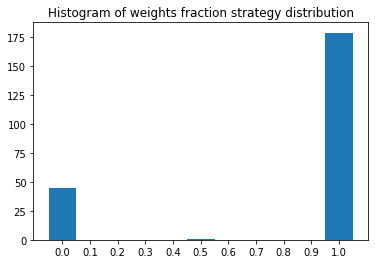

```
{('benchmark (computing)', 'particle swarm optimization'): 1.0, ('benchmark (computing)', 'mathematical optimization'): 1.0, ('particle swarm optimization', 'mathematical optimization'): 0.6, ('stochastic process', 'algorithm'): 1.0, ('algorithm', 'reinforcement learning'): 1.0, ('random number gene…



Weights config: number of co-citated keywords.
```

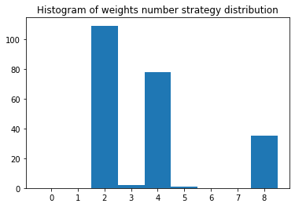

```
{('benchmark (computing)', 'particle swarm optimization'): 2, ('benchmark (computing)', 'mathematical optimization'): 2, ('particle swarm optimization', 'mathematical optimization'): 5, ('stochastic process', 'algorithm'): 2, ('algorithm', 'reinforcement learning'): 2, ('random number generation', '…
```

```python
print("Year: 2004{0}".format('\n'))

year_weights_configs("2004")
```

## Year 2005

```
Year: 2005

Weights config: fraction of co-citations keywords by cooperating authors.
```

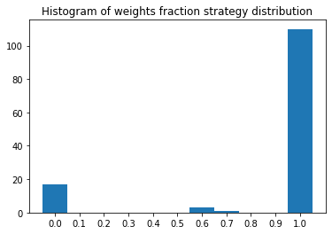

```
{('benchmark (computing)', 'particle swarm optimization'): 0.6666666666666666, ('benchmark (computing)', 'evolutionary computation'): 0.0, ('benchmark (computing)', 'simulation'): 0.0, ('benchmark (computing)', 'genetic algorithm'): 0.0, ('benchmark (computing)', 'mathematical optimization'): 0.7777…



Weights config: number of co-citated keywords.
```

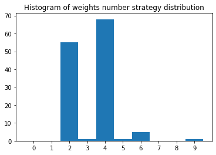

```
{('benchmark (computing)', 'particle swarm optimization'): 6, ('benchmark (computing)', 'evolutionary computation'): 2, ('benchmark (computing)', 'simulation'): 2, ('benchmark (computing)', 'genetic algorithm'): 2, ('benchmark (computing)', 'mathematical optimization'): 9, ('particle swarm optimizat…
```

```python
print("Year: 2005{0}".format('\n'))

year_weights_configs("2005")
```

## Year 2006

```
Year: 2006

Weights config: fraction of co-citations keywords by cooperating authors.
```

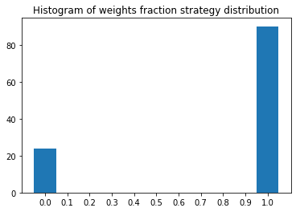

```
{('particle swarm optimization', 'algorithm'): 1.0, ('paper presents', 'frw method'): 1.0, ('artificial neural network', 'time-varying delays'): 1.0, ('periodic solution', 'time-varying delays'): 1.0, ('linear matrix inequality', 'computationally efficient'): 1.0, ('linear matrix inequality', 'suffi…



Weights config: number of co-citated keywords.
```

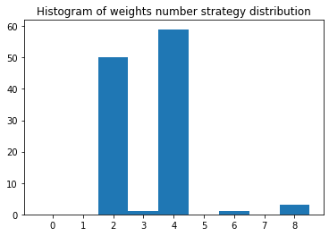

```
{('particle swarm optimization', 'algorithm'): 2, ('paper presents', 'frw method'): 4, ('artificial neural network', 'time-varying delays'): 2, ('periodic solution', 'time-varying delays'): 2, ('linear matrix inequality', 'computationally efficient'): 2, ('linear matrix inequality', 'sufficient cond…
```

```python
print("Year: 2006{0}".format('\n'))

year_weights_configs("2006")
```

## Year 2007

```
Year: 2007

Weights config: fraction of co-citations keywords by cooperating authors.
```

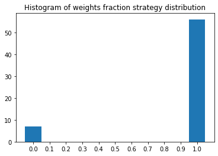

```
{('particle swarm optimization', 'velocity (software development)'): 1.0, ('particle swarm optimization', 'mathematical optimization'): 1.0, ('velocity (software development)', 'mathematical optimization'): 1.0, ('artificial neural network', 'linear matrix inequality'): 1.0, ('artificial neural netw…



Weights config: number of co-citated keywords.
```

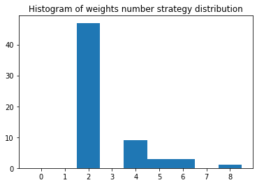

```
{('particle swarm optimization', 'velocity (software development)'): 2, ('particle swarm optimization', 'mathematical optimization'): 2, ('velocity (software development)', 'mathematical optimization'): 2, ('artificial neural network', 'linear matrix inequality'): 5, ('artificial neural network', 't…
```

```python
print("Year: 2007{0}".format('\n'))

year_weights_configs("2007")
```

## Year 2008

```
Year: 2008

Weights config: fraction of co-citations keywords by cooperating authors.
```

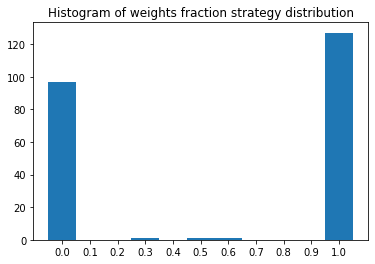

```
{('algorithm', 'computation'): 1.0, ('numerical analysis', 'mathematical optimization'): 1.0, ('numerical analysis', 'social inequality'): 1.0, ('mathematical optimization', 'social inequality'): 1.0, ('paper presents', 'advanced cross'): 1.0, ('paper presents', 'lingual information access'): 1.0, (…



Weights config: number of co-citated keywords.
```

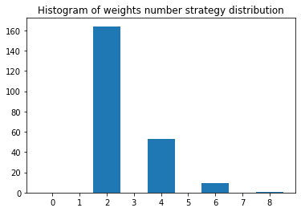

```
{('algorithm', 'computation'): 2, ('numerical analysis', 'mathematical optimization'): 4, ('numerical analysis', 'social inequality'): 4, ('mathematical optimization', 'social inequality'): 4, ('paper presents', 'advanced cross'): 4, ('paper presents', 'lingual information access'): 4, ('paper prese…
```

```python
print("Year: 2008{0}".format('\n'))

year_weights_configs("2008")
```

## Year 2009

```
Year: 2009

Weights config: fraction of co-citations keywords by cooperating authors.
```

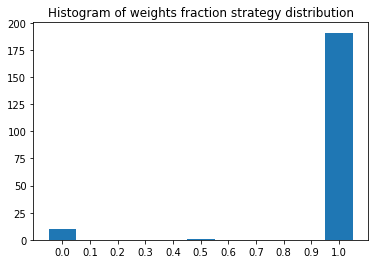

```
{('cognitive radio', 'frequency band'): 1.0, ('cognitive radio', 'interference (communication)'): 1.0, ('mathematical optimization', 'evolutionary algorithm'): 1.0, ('particle swarm optimization', 'mathematical optimization'): 1.0, ('algorithm', 'mathematical optimization'): 1.0, ('mathematical opti…



Weights config: number of co-citated keywords.
```

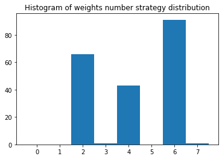

```
{('cognitive radio', 'frequency band'): 2, ('cognitive radio', 'interference (communication)'): 2, ('mathematical optimization', 'evolutionary algorithm'): 2, ('particle swarm optimization', 'mathematical optimization'): 7, ('algorithm', 'mathematical optimization'): 2, ('mathematical optimization',…
```

```python
print("Year: 2009{0}".format('\n'))

year_weights_configs("2009")
```

## Year 2010

```
Year: 2010

Weights config: fraction of co-citations keywords by cooperating authors.
```

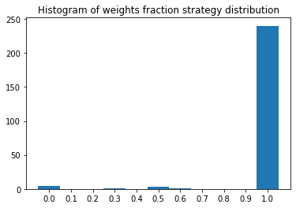

```
{('particle swarm optimization', 'mathematical optimization'): 1.0, ('numerical analysis', 'mathematical optimization'): 0.5, ('self-organization', 'multi-agent system'): 1.0, ('self-organization', 'coexist (image)'): 1.0, ('self-organization', 'interference (communication)'): 1.0, ('self-organizati…



Weights config: number of co-citated keywords.
```

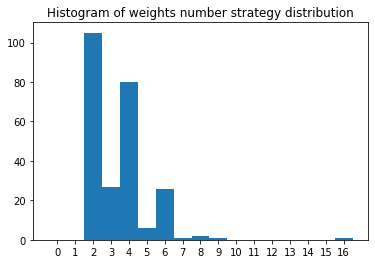

```
{('particle swarm optimization', 'mathematical optimization'): 2, ('numerical analysis', 'mathematical optimization'): 4, ('self-organization', 'multi-agent system'): 3, ('self-organization', 'coexist (image)'): 2, ('self-organization', 'interference (communication)'): 3, ('self-organization', 'algo…
```

```python
print("Year: 2010{0}".format('\n'))

year_weights_configs("2010")
```

## Year 2011

```
Year: 2011

Weights config: fraction of co-citations keywords by cooperating authors.
```

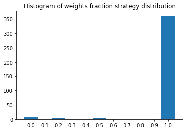

```
{('linear matrix inequality', 'lyapunov fractal'): 0.3333333333333333, ('interference (communication)', 'multitier architecture'): 1.0, ('interference (communication)', 'signal-to-interference-plus-noise ratio'): 1.0, ('checking (action)', 'lyapunov fractal'): 1.0, ('lyapunov fractal', 'exponential'…



Weights config: number of co-citated keywords.
```

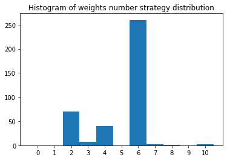

```
{('linear matrix inequality', 'lyapunov fractal'): 6, ('interference (communication)', 'multitier architecture'): 2, ('interference (communication)', 'signal-to-interference-plus-noise ratio'): 2, ('checking (action)', 'lyapunov fractal'): 2, ('lyapunov fractal', 'exponential'): 2, ('lyapunov fracta…
```

```python
print("Year: 2011{0}".format('\n'))

year_weights_configs("2011")
```

## Year 2012

```
Year: 2012

Weights config: fraction of co-citations keywords by cooperating authors.
```

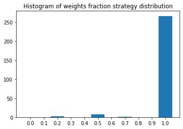

```
{('artificial neural network', 'dropout (neural networks)'): 1.0, ('artificial neural network', 'overfitting'): 1.0, ('artificial neural network', 'test data'): 1.0, ('dropout (neural networks)', 'overfitting'): 1.0, ('dropout (neural networks)', 'test data'): 1.0, ('overfitting', 'test data'): 1.0,…



Weights config: number of co-citated keywords.
```

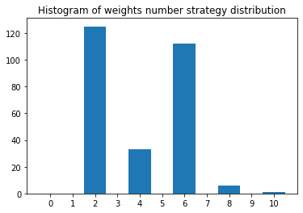

```
{('artificial neural network', 'dropout (neural networks)'): 4, ('artificial neural network', 'overfitting'): 4, ('artificial neural network', 'test data'): 4, ('dropout (neural networks)', 'overfitting'): 4, ('dropout (neural networks)', 'test data'): 4, ('overfitting', 'test data'): 4, ('data mini…
```

```python
print("Year: 2012{0}".format('\n'))

year_weights_configs("2012")
```

## Year 2013

```
Year: 2013

Weights config: fraction of co-citations keywords by cooperating authors.
```

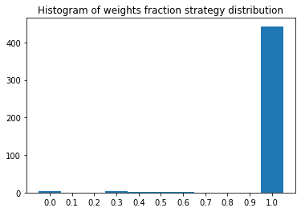

```
{('linear matrix inequality', 'social inequality'): 1.0, ('linguistic frame semantics', 'ontology design'): 1.0, ('linguistic frame semantics', 'ready ontologies'): 1.0, ('linguistic frame semantics', 'novel approach'): 1.0, ('linguistic frame semantics', 'converting text'): 1.0, ('linguistic frame …



Weights config: number of co-citated keywords.
```

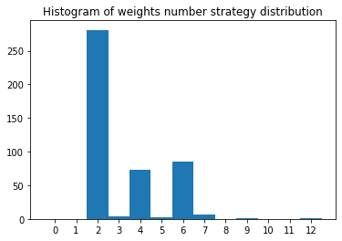

```
{('linear matrix inequality', 'social inequality'): 7, ('linguistic frame semantics', 'ontology design'): 4, ('linguistic frame semantics', 'ready ontologies'): 4, ('linguistic frame semantics', 'novel approach'): 4, ('linguistic frame semantics', 'converting text'): 4, ('linguistic frame semantics'…
```

```python
print("Year: 2013{0}".format('\n'))

year_weights_configs("2013")
```

## Year 2014

```
Year: 2014

Weights config: fraction of co-citations keywords by cooperating authors.
```

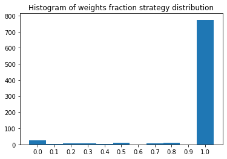

```
{('artificial neural network', 'deep learning'): 1.0, ('artificial neural network', 'computer vision'): 1.0, ('multimodal interaction', 'language model'): 1.0, ('iterative method', 'algorithm'): 1.0, ('analytical models', 'topology'): 1.0, ('analytical models', 'mathematical model'): 1.0, ('topology…



Weights config: number of co-citated keywords.
```

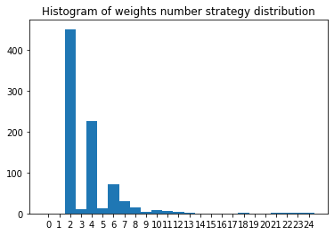

```
{('artificial neural network', 'deep learning'): 2, ('artificial neural network', 'computer vision'): 2, ('multimodal interaction', 'language model'): 4, ('iterative method', 'algorithm'): 5, ('analytical models', 'topology'): 3, ('analytical models', 'mathematical model'): 2, ('topology', 'mathemat…
```

```python
print("Year: 2014{0}".format('\n'))

year_weights_configs("2014")
```

## Year 2015

```
Year: 2015

Weights config: fraction of co-citations keywords by cooperating authors.
```

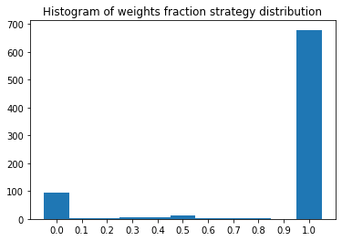

```
{('artificial neural network', 'imagenet'): 1.0, ('artificial neural network', 'convolutional neural network'): 0.75, ('artificial neural network', 'computer vision'): 1.0, ('imagenet', 'convolutional neural network'): 1.0, ('imagenet', 'computer vision'): 1.0, ('convolutional neural network', 'comp…



Weights config: number of co-citated keywords.
```

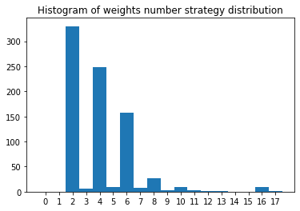

```
{('artificial neural network', 'imagenet'): 10, ('artificial neural network', 'convolutional neural network'): 8, ('artificial neural network', 'computer vision'): 10, ('imagenet', 'convolutional neural network'): 4, ('imagenet', 'computer vision'): 10, ('convolutional neural network', 'computer vis…
```

```python
print("Year: 2015{0}".format('\n'))

year_weights_configs("2015")
```